# Ford GoBike Data Exploration

## Introduction

> This data set includes information about individual rides made in a bike-sharing system covering the greater San Francisco Bay area. It icludes data such as the duration of the ride, starting time, end time, station name, gender, and other valuable data.

## Preliminary Wrangling

```python
# import all packages and set plots to be embedded inline
import numpy as np
import pandas as pd
import matplotlib.pyplot as plt
import seaborn as sns


%matplotlib inline

import warnings
warnings.simplefilter('ignore')
```

Load the dataset

```python
#Load the dataset
df = pd.read_csv("201902-fordgobike-tripdata.csv")

df.head()
```

|  | duration_sec | start_time | end_time | start_station_id | start_station_name | start_station_latitude | start_station_longitude | end_station_id | end_station_name | end_station_latitude | end_station_longitude | bike_id | user_type | member_birth_year | member_gender | bike_share_for_all_trip |
| --- | --- | --- | --- | --- | --- | --- | --- | --- | --- | --- | --- | --- | --- | --- | --- | --- |
| 0 | 52185 | 2019-02-28 17:32:10.1450 | 2019-03-01 08:01:55.9750 | 21.0 | Montgomery St BART Station (Market St at 2nd St) | 37.789625 | -122.400811 | 13.0 | Commercial St at Montgomery St | 37.794231 | -122.402923 | 4902 | Customer | 1984.0 | Male | No |
| 1 | 42521 | 2019-02-28 18:53:21.7890 | 2019-03-01 06:42:03.0560 | 23.0 | The Embarcadero at Steuart St | 37.791464 | -122.391034 | 81.0 | Berry St at 4th St | 37.775880 | -122.393170 | 2535 | Customer | NaN | NaN | No |
| 2 | 61854 | 2019-02-28 12:13:13.2180 | 2019-03-01 05:24:08.1460 | 86.0 | Market St at Dolores St | 37.769305 | -122.426826 | 3.0 | Powell St BART Station (Market St at 4th St) | 37.786375 | -122.404904 | 5905 | Customer | 1972.0 | Male | No |
| 3 | 36490 | 2019-02-28 17:54:26.0100 | 2019-03-01 04:02:36.8420 | 375.0 | Grove St at Masonic Ave | 37.774836 | -122.446546 | 70.0 | Central Ave at Fell St | 37.773311 | -122.444293 | 6638 | Subscriber | 1989.0 | Other | No |
| 4 | 1585 | 2019-02-28 23:54:18.5490 | 2019-03-01 00:20:44.0740 | 7.0 | Frank H Ogawa Plaza | 37.804562 | -122.271738 | 222.0 | 10th Ave at E 15th St | 37.792714 | -122.248780 | 4898 | Subscriber | 1974.0 | Male | Yes |

```python
#Check the shape of the dataset
df.shape
```

```
(183412, 16)
```

```python
#Chech the datatypes of the variables in the dataset
df.dtypes
```

```
duration_sec                 int64
start_time                  object
end_time                    object
start_station_id           float64
start_station_name          object
start_station_latitude     float64
start_station_longitude    float64
end_station_id             float64
end_station_name            object
end_station_latitude       float64
end_station_longitude      float64
bike_id                      int64
user_type                   object
member_birth_year          float64
member_gender               object
bike_share_for_all_trip     object
dtype: object
```

Convert the datatype of **start_time** and **end_time** columns to datatime

```python
df["start_time"] = pd.to_datetime(df["start_time"])
df["end_time"] = pd.to_datetime(df["end_time"])

print("start_time datatype: ", df["start_time"].dtypes)
print("end_time datatype: ",df["end_time"].dtypes)
```

```
start_time datatype:  datetime64[ns]
end_time datatype:  datetime64[ns]
```

```python
df["user_type"].unique()
```

```
array(['Customer', 'Subscriber'], dtype=object)
```

```python
# Convert user_type to categorical variable
user_category = pd.api.types.CategoricalDtype(ordered=False, categories=['Customer', 'Subscriber'])
df["user_type"] = df["user_type"].astype(user_category)

df["user_type"].dtype
```

```
CategoricalDtype(categories=['Customer', 'Subscriber'], ordered=False)
```

#### Check if there are any missing data

```python
df.isna().sum()
```

```
duration_sec                  0
start_time                    0
end_time                      0
start_station_id            197
start_station_name          197
start_station_latitude        0
start_station_longitude       0
end_station_id              197
end_station_name            197
end_station_latitude          0
end_station_longitude         0
bike_id                       0
user_type                     0
member_birth_year          8265
member_gender              8265
bike_share_for_all_trip       0
dtype: int64
```

It is interesting to note that the missing data total up to 197 and 8265. Let's check whether the missing data fall in the same rows.

```python
#Start with those with missing 197 values

mask = df["start_station_id"].isna()
mask1 = df["start_station_name"].isna()
mask2 = df["end_station_name"].isna()
mask3 = df["end_station_id"].isna()

df[mask &mask1 & mask2 & mask3].shape
```

```
(197, 16)
```

The missing data fall in the same rows.

```python
# Check those with missing 8265 values
mask1 = df["member_birth_year"].isna()
mask2 = df["member_gender"].isna()

df[mask1 & mask2].shape
```

```
(8265, 16)
```

The users whose birth year is missing also didn't record their gender. This means we would notlose a lot of data when we drop the rows with missing values.

```python
#Drop all rows containing the missing data

df.dropna(inplace=True)
df.shape
```

```
(174952, 16)
```

```python
# Descriptive statistics
df.describe()
```

|  | duration_sec | start_station_id | start_station_latitude | start_station_longitude | end_station_id | end_station_latitude | end_station_longitude | bike_id | member_birth_year |
| --- | --- | --- | --- | --- | --- | --- | --- | --- | --- |
| count | 174952.000000 | 174952.000000 | 174952.000000 | 174952.000000 | 174952.000000 | 174952.000000 | 174952.000000 | 174952.000000 | 174952.000000 |
| mean | 704.002744 | 139.002126 | 37.771220 | -122.351760 | 136.604486 | 37.771414 | -122.351335 | 4482.587555 | 1984.803135 |
| std | 1642.204905 | 111.648819 | 0.100391 | 0.117732 | 111.335635 | 0.100295 | 0.117294 | 1659.195937 | 10.118731 |
| min | 61.000000 | 3.000000 | 37.317298 | -122.453704 | 3.000000 | 37.317298 | -122.453704 | 11.000000 | 1878.000000 |
| 25% | 323.000000 | 47.000000 | 37.770407 | -122.411901 | 44.000000 | 37.770407 | -122.411647 | 3799.000000 | 1980.000000 |
| 50% | 510.000000 | 104.000000 | 37.780760 | -122.398279 | 101.000000 | 37.781010 | -122.397437 | 4960.000000 | 1987.000000 |
| 75% | 789.000000 | 239.000000 | 37.797320 | -122.283093 | 238.000000 | 37.797673 | -122.286533 | 5505.000000 | 1992.000000 |
| max | 84548.000000 | 398.000000 | 37.880222 | -121.874119 | 398.000000 | 37.880222 | -121.874119 | 6645.000000 | 2001.000000 |

It is interesting to note that the shortest ride lasted only for a **minute** and the longest lasting for almost a **whole day!**. This two cases could be outliers.

# Create new columns

```python
# Create minutes column
df["duration_min"] = df["duration_sec"] / 60
```

All the rides took place in 2019. We would subtract this from the **member_birth_year** column to get the age of the rider at the time.

```python
# Create age column
df["age"] = 2019 - df["member_birth_year"]
df["age"] = df["age"].astype("int")
```

```python
# Categorise ages into groups for easier data analysis

bins = np.arange(10,121, 10)
labels = ['10-19','20-29','30-39','40-49','50-59','60-69','70-79','80-89','90-99','100-109','110-119']
df['age_group'] = pd.cut(df['age'], bins=bins, labels=labels, right=False)
```

### What is the structure of your dataset?

There are 174952 observations in the dataset with 16 features with the following datatypes:

- **Object**: start_station_name, end_station_name, member_gender and bike_share_for_all_trip
- **Float**: start_station_id, start_station_latitude, start_station_longitude, end_station_id, end_station_latitude, end_station_longitude and member_birth_year
- **Int**: duration_sec and bike_id
- **Categorical**: user_type

### What is/are the main feature(s) of interest in your dataset?

I most interested in the features that are suitable for predicting the duration of a trip.

### What features in the dataset do you think will help support your investigation into your feature(s) of interest?

> I believe that the user type will be a strong factor in determining the length of a ride. I also believe that the start time and age will be cotributing factors.

## Univariate Exploration

I will start by looking at the distribution of the ride duration (**duration_sec**):

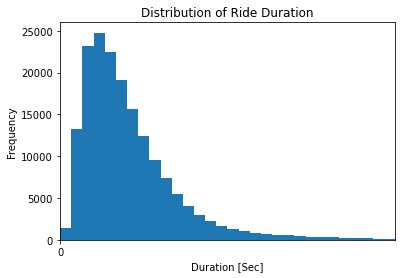

```python
def plot_hist(x, bins, xlim,title, xlabel, ylabel="Frequency"):
    '''
    Plots a histogram

    Parameter:
    x : x variable
    bins = constom bins to use for the plot
    xlim: Limit values for x variables
    title: title of the plot
    xlabel: x-axis label
    ylabel: y-axis label (Optional)
    '''

    plt.hist(data=df, x =x, bins = bins)
    plt.xlim(xlim)
    plt.xlabel(xlabel)
    plt.ylabel(ylabel)
    plt.title(title)

sns.countplot()
bins = np.arange(0, df["duration_sec"].max()+100, 100)
plot_hist("duration_sec", bins, (0,3000), "Distribution of Ride Duration", "Duration [Sec]" );
```

The distribution is skewed to the right. Let's try to transform the data and plot again.

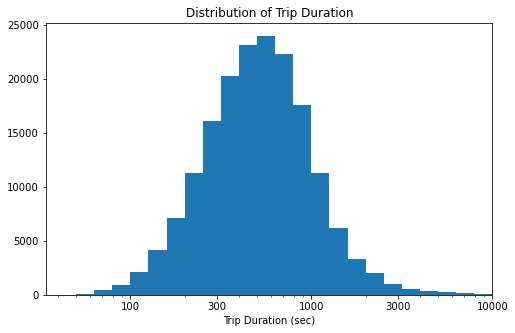

```python
log_binsize = 0.1
bins = 10 ** np.arange(1.7,  np.log10(df['duration_sec']).max() + log_binsize, log_binsize)
ticks =  [100, 300, 1000, 3000, 10000, 30000, 100000]
labels = ['{}'.format(v) for v in ticks]

plt.figure(figsize=[8, 5])
plt.hist(data = df, x = 'duration_sec', bins = bins)
plt.xscale('log')
plt.xticks(ticks, labels)
plt.xlim(0, 10000)
plt.xlabel('Trip Duration (sec)')
plt.title('Distribution of Trip Duration')
plt.show();
```

### Distribution of User Types

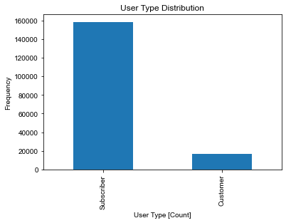

```python
user_types = df["user_type"].value_counts()

# Function for plotting bar charts
def plot_bar(data, xlabel, ylabel, title, kind='bar'):
    '''
    Plots a bar chart

    Parameter:
    data: Pandas DataFrame/ Series
    xlabel: x-axis label
    ylabel: y-axis label (Optional)
    title: title of the plot
    '''

    data.plot(kind=kind)

    plt.xlabel(xlabel)
    plt.ylabel(ylabel)
    plt.title(title)
    plt.style.use("seaborn")


plot_bar(user_types, "User Type [Count]", "Frequency", "User Type Distribution")
```

Almost all the users are subscribers.

Most Ford GoBike users are males. They are three times more than female counterparts.

### Distribution of Users Age

We hav to create an age column to store the age of the rider at the year in which they took the ride.

```python
# Check the year the ride was made
df["start_time"].dt.year.unique()
```

```
array([2019], dtype=int64)
```

[output not shown]

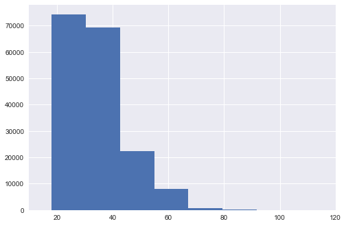

```python
# Plot the distribution
df["age"].hist();
plt.xlim(10, 120)
```

Most users are between the ages of 20 and 40.

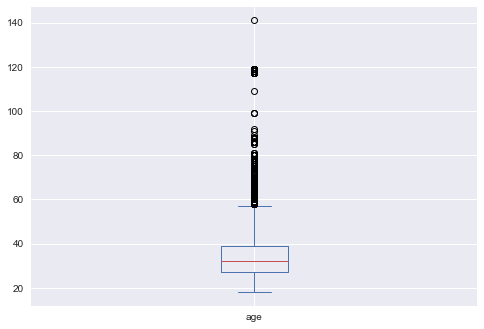

```python
#Check whether there are any outliers in the age data
df["age"].plot(kind="box");
```

```python
# There is an outlier of a rider aged 141. We have to remove this outlier.

mask = df["age"] < 120

df = df[mask].copy()
```

### Distribution of Gender

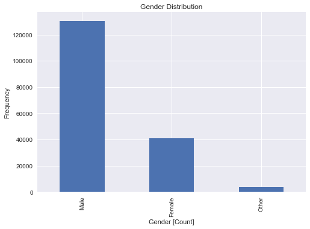

```python
gender_data = df["member_gender"].value_counts().plot(kind="bar");

# Plot
plot_bar(gender_data, "Gender [Count]", "Frequency", "Gender Distribution")
```

### Distribution of Start Time

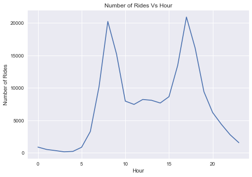

```python
df["start_hour"] = df["start_time"].dt.hour # Create start_hour column from the hour portion from start time

df_duration = (
    df["start_hour"]
    .value_counts() # Total counts for each hour
    .sort_index() # Sort by hour
    )


def plot_line(df, xlabel, ylabel, title):
    '''
    Plots a line graph

    Parameter:
    df: Pandas DataFrame/ Series
    xlabel: x-axis label
    ylabel: y-axis label (Optional)
    title: title of the plot
    '''
    df.plot(kind="line")
    plt.xlabel(xlabel)
    plt.ylabel(ylabel)
    plt.title(title)


plot_line(df_duration, "Hour", "Number of Rides", "Number of Rides Vs Hour")
```

### Discuss the distribution(s) of your variable(s) of interest. Were there any unusual points? Did you need to perform any transformations?

> The distribution of the duration is skewed to the right and a log transformation was necessary to better visualize the data.

## Bivariate Exploration

> We would begin by looking at the relationship between **ride duration** and the **age** of the user.

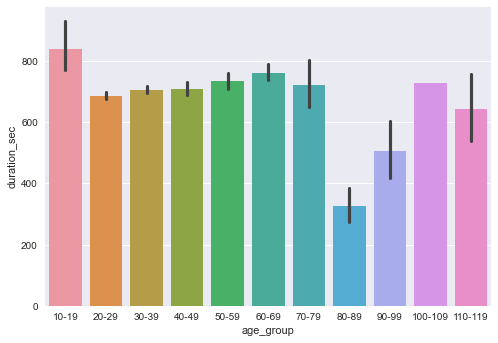

```python
sns.barplot(data=df, x="age_group", y="duration_sec");
```

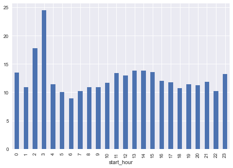

```python
df.groupby("start_hour")["duration_min"].mean().plot(kind="bar");
```

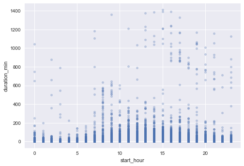

```python
df["duration_min"] = df["duration_sec"] / 60
df.plot(kind="scatter",  x="start_hour", y="duration_min", alpha=0.3);
```

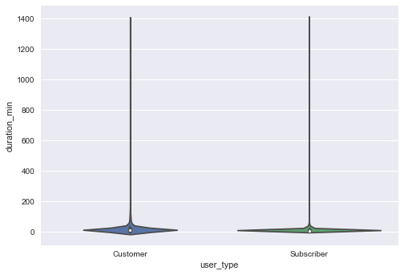

```python
sns.violinplot(data=df, x="user_type", y="duration_min");
```

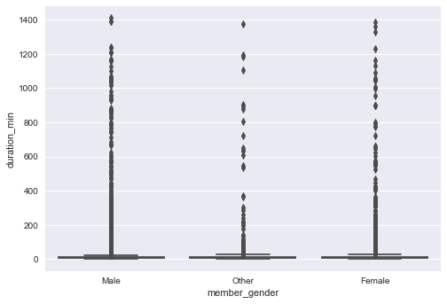

```python
sns.boxplot(data=df, x="member_gender", y="duration_min");
```

##### What is the trend in ride duration through the days of the month?

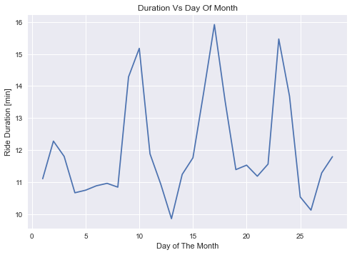

```python
df["day_of_month"] = df["start_time"].dt.day

df_day_of_month = df.groupby("day_of_month")["duration_min"].mean();

plot_line(df_day_of_month, "Day of The Month", "Ride Duration [min]", "Duration Vs Day Of Month")
```

It is interesting to note that the peaks in ride duration fall on weekends. Generally, the ride duration is short on week days.

### What is the trend in ride duration through the days of the week?

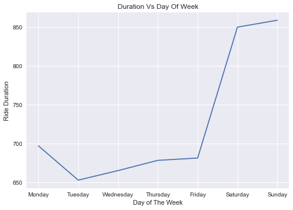

```python
df["day_of_week"] = df["start_time"].dt.dayofweek
ticks = np.arange(7)
days = ['Monday', 'Tuesday', 'Wednesday', 'Thursday', 'Friday', 'Saturday', 'Sunday']
df_day_of_week = df.groupby("day_of_week")["duration_sec"].mean()

plot_line(df_day_of_week, "Day of The Week", "Ride Duration", "Duration Vs Day Of Week")

plt.xticks(ticks,days);
```

Most users have the longest rides over the weekends as compared to week days.

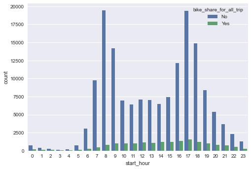

```python
sns.countplot(data = df, x = 'start_hour', hue = 'bike_share_for_all_trip');
```

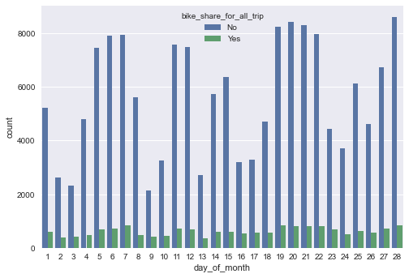

```python
sns.countplot(data = df, x = 'day_of_month', hue = 'bike_share_for_all_trip');
```

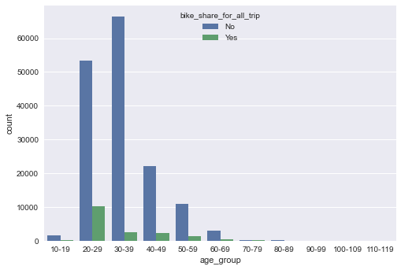

```python
bins = np.arange(10,121, 10)

labels = ['10-19','20-29','30-39','40-49','50-59','60-69','70-79','80-89','90-99','100-109','110-119']
df['age_group'] = pd.cut(df['age'], bins=bins, labels=labels, right=False)


sns.countplot(data = df, x = 'age_group', hue = 'bike_share_for_all_trip');
```

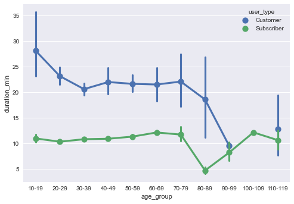

```python
sns.pointplot(data=df, x="age_group", y="duration_min", hue="user_type");
```

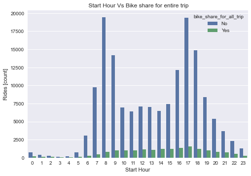

```python
sns.countplot(data = df, x = 'start_hour', hue = 'bike_share_for_all_trip')
plt.xlabel("Start Hour")
plt.ylabel("Rides [count]")
plt.title(" Start Hour Vs Bike share for entire trip");
```

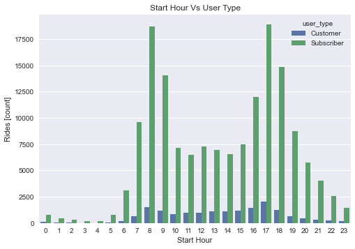

```python
sns.countplot(data = df, x = 'start_hour', hue = 'user_type')
plt.xlabel("Start Hour")
plt.ylabel("Rides [count]")
plt.title("Start Hour Vs User Type");
```

### Talk about some of the relationships you observed in this part of the investigation. How did the feature(s) of interest vary with other features in the dataset?

> The day of the week is a big determinant on the duration of the ride. Generally, ride durations are shorter on week days as compared to weekends. Also the hour of day seem to correlate with the duration of the ride

### Did you observe any interesting relationships between the other features (not the main feature(s) of interest)?

> Most of the users are youth between the age of 20-39. It is also noted that a huge majority of the users are subscribers.

## Multivariate Exploration

### How does gender and user type affect trip duration?

[figure not shown]

```python
# create bar plot on gender versus duration on levels of the age bins variable
plt.figure(figsize = [8, 8])

ax = sns.barplot(x='member_gender', y = 'duration_min', hue='user_type', data=df.sort_values(by= 'user_type'))
plt.title('Trip Duration Across Gender and Age Group')
plt.xlabel('Gender')
plt.ylabel('Duration (min)')
leg = ax.legend()
```

The **other** gender seem to take the longest rides for both subscribers and customers. It is also noted that for all genders, customers take the longest rides.

# How does ride duration vary with user type and the start hour?

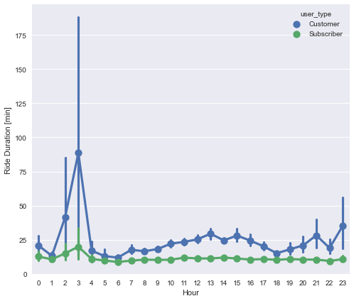

```python
plt.figure(figsize = (8, 7))
sns.pointplot(data=df, x='start_hour', y='duration_min', hue='user_type')
plt.xlabel('Hour');
plt.ylabel('Ride Duration [min]');
plt.show()
```

The longest rides are witnessed at 3 a.m for both customers and subscribers. It is also noted that, generally, customers take the longest rides at any hour of the day.

#### How does ride duration vary based on days of the week and user type?

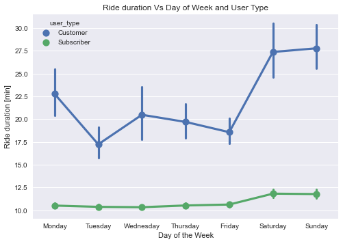

```python
sns.pointplot(data = df, x = 'day_of_week', y='duration_min', hue = 'user_type')
ticks = np.arange(0,7)
labels = ['Monday', 'Tuesday', 'Wednesday', 'Thursday', 'Friday', 'Saturday', 'Sunday']

plt.xlabel("Day of the Week")
plt.ylabel("Ride duration [min]")
plt.title("Ride duration Vs Day of Week and User Type")
plt.xticks(ticks,labels);
```

The longest rides are witsessed during the weekends for both customers and subscribers. It is also clear that customers take the longest rides on any day compared to subscibers.

### Talk about some of the relationships you observed in this part of the investigation. Were there features that strengthened each other in terms of looking at your feature(s) of interest?

> The **day of the week** and **user type** have proven to be strong predictors for determining the duration of a ride. Users take longer rides on Weekends as compared to weekdays. Customers take the longest rides for all genders and during any day or hour.

### Were there any interesting or surprising interactions between features?

> I did not expect customers to take longer rides as compared to subscribers. It was also interesting to note that the longest rides during the day are witnessed at 3 a.m.

```python
#Save the cleaned dataset
df.to_csv("201902-fordgobike-tripdata_cleaned.csv", index=False)
```